# Confidence estimation

[Matt Jaquiery](https://github.com/mjaquiery) (matt.jaquiery@psy.ox.ac.uk)

December 2019

[Script run 2020-01-21 18:06:58]

# Introduction

Observations from [evolutionary models](https://github.com/oxacclab/EvoEgoBias) show that egocentric discounting is a successful strategy in environments where advisors cannot be clear on how advisors’ expressed confidence relates to their actual confidence. We reason that human participants may show a sensitivity to these contextual factors underlying advice-taking and respond to them in a rational manner. To test the effects of known versus unknown confidence representations, we manipulated whether participants believed advice to come from a consistent advisor or from one of a number of advisors on each trial in a judge-advisor system. Participants had two experimental blocks: in one the advice they received was always labeled as coming from a consistent individual, while in the other the advice was labeled as coming from a different advisor each time. All advice was drawn from the same distribution, which was centred on the correct answer (i.e. all of the advice was helpful on average).

After 10 trials in each block in which feedback on the correct answers was provided so participants could learn about the advisor/s, participants performed 5 trials without feedback.

We hypothesised that participants would place greater weight on the advice of the consistent advisor, presumably because they are able to learn about the calibration of the individual advisor while they cannot do likewise for the population of advisors.

# Method

The experimental code is available on [GitHub](https://github.com/oxacclab/ExploringSocialMetacognition), and the experiment can be performed by visiting [https://acclab.psy.ox.ac.uk/~mj221/ESM/ACBin/ce.html](https://acclab.psy.ox.ac.uk/~mj221/ESM/ACBin/ce.html?PROLIFIC_PID=WriteUp).

# Results

## Exclusions

```
##
##                  SingleFirst GroupFirst
##   FALSE                   15         15
##   outlyingTrials           2          1
```

Our final participant list consists of 30 participants who completed an average of 27.90 trials each, of which an average of 9.90 had no feedback.

## Task performance

First we offer a characterisation of the task, to provide the reader with a sense of how the participants performed.

### Decisions

Participants offered estimates of whether various events took place before or after a given year. The correct answers were always between 1900 and 2000. Participants answered by selecting a point on one of two confidence bars, with the choice of bar indicating the chosen answer.

#### Correctness

| decision | mean | CL95.Low | CL95.High |
| --- | --- | --- | --- |
| first | .583 | .535 | .632 |
| last | .711 | .679 | .743 |
| Overall | .647 | .611 | .684 |

| decision | mean | CL95.Low | CL95.High | feedback |
| --- | --- | --- | --- | --- |
| first | .578 | .516 | .640 | TRUE |
| last | .717 | .677 | .756 | TRUE |
| Overall | .647 | .601 | .694 | TRUE |

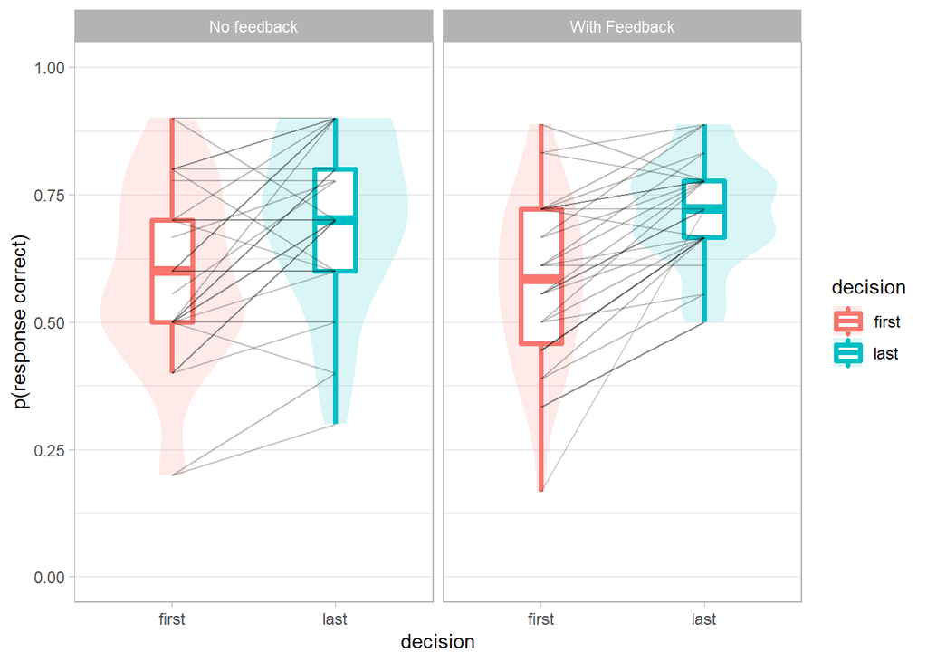

### Timing

We can look at the response time - the difference between the time the response is opened and the time the response is received.

| decision | mean | CL95.Low | CL95.High |
| --- | --- | --- | --- |
| first | 5383 | 4503 | 6262 |
| last | 8949 | 7965 | 9933 |
| Overall | 7166 | 6239 | 8093 |

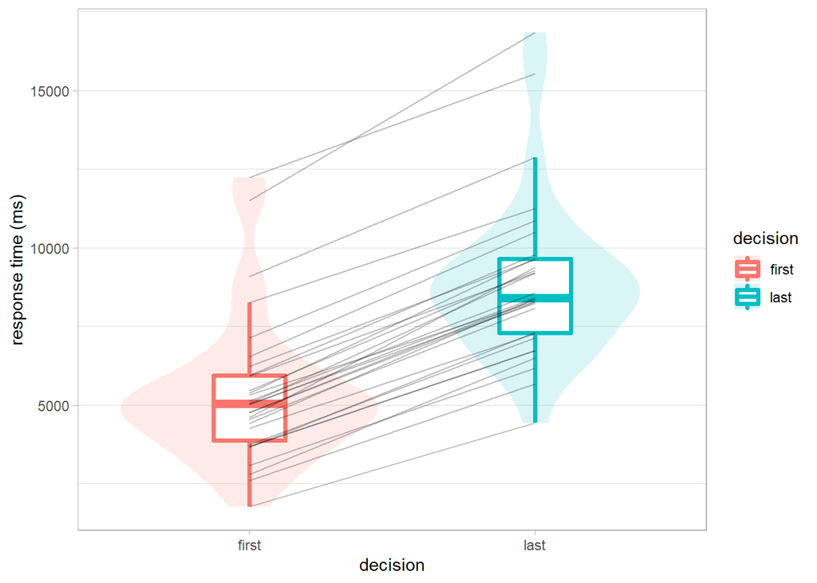

## Metacognitive performance

Participants indicated the confidence in their decisions simultaneously with the decisions themselves. We can thus explore how well a participant’s confidence signals their accuracy. We provide only a brief examination here where normalised responses are split into high and low confidence for each participant, and the accuracies of the two categories are compared. This is done separately for first and last decisions.

| decision | mean | CL95.Low | CL95.High |
| --- | --- | --- | --- |
| first | -.007 | -.087 | .073 |
| last | .144 | .063 | .224 |
| Overall | .068 | .015 | .122 |

```
## [1] "p(correct|high confidence) - p(correct|low confidence) for initial estimates"
```

```
## Bayes factor analysis
## --------------
## [1] Alt., r=0.707 : 0.1970142 ±0.01%
##
## Against denominator:
##   Null, mu = 0
## ---
## Bayes factor type: BFoneSample, JZS
```

```
## [1] "p(correct|high confidence) - p(correct|low confidence) for final decisions"
```

```
## Bayes factor analysis
## --------------
## [1] Alt., r=0.707 : 33.3622 ±0%
##
## Against denominator:
##   Null, mu = 0
## ---
## Bayes factor type: BFoneSample, JZS
```

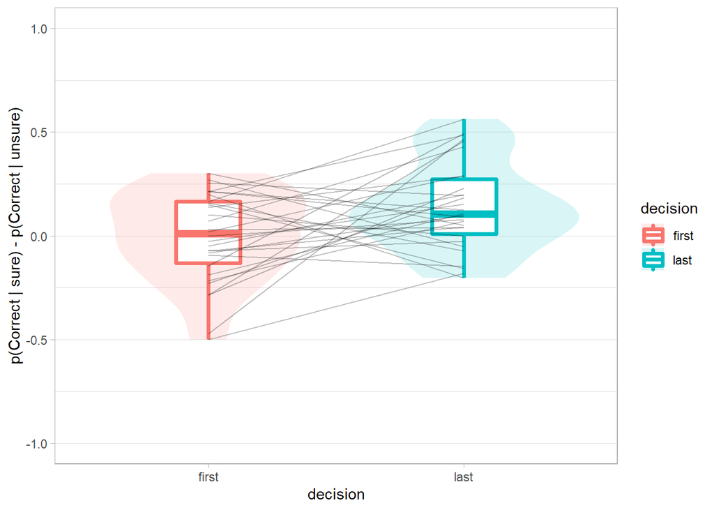

## Advisor performance

The advice offered should be equivalent between single/group advisors.

### Accuracy

| advisor0idDescription | feedback | advisorAccuracy | advisorAgree |
| --- | --- | --- | --- |
| mass | FALSE | .765 | .588 |
| mass | TRUE | .719 | .607 |
| single | FALSE | .753 | .597 |
| single | TRUE | .781 | .596 |

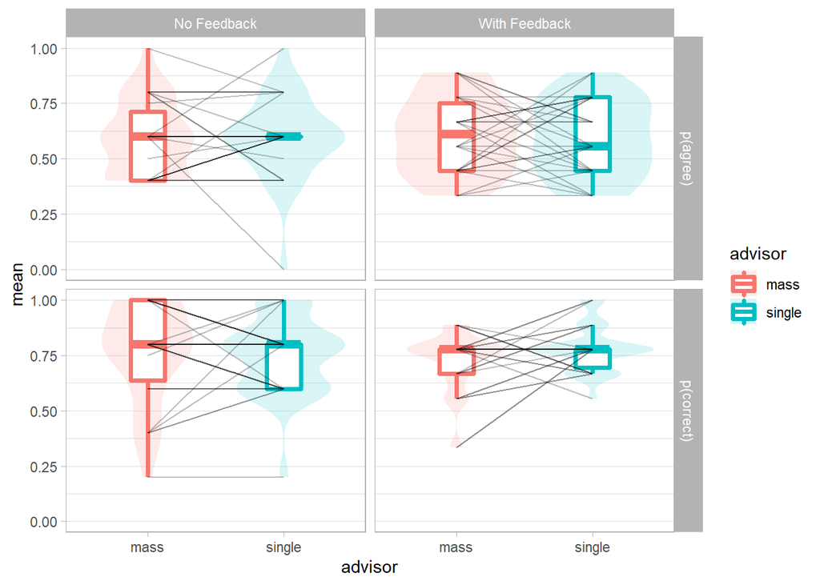

### Distance

Distance is the continuous version of agreement - the difference along the confidence scale between the advice and the initial estimate. Where different scales are endorsed, the difference is the combination of how sure the participant was on one scale plus how sure the advisor was on the other.

| advisor0idDescription | feedback | adviceDistance |
| --- | --- | --- |
| mass | FALSE | 55.2 |
| mass | TRUE | 56.8 |
| single | FALSE | 54.5 |
| single | TRUE | 59.4 |

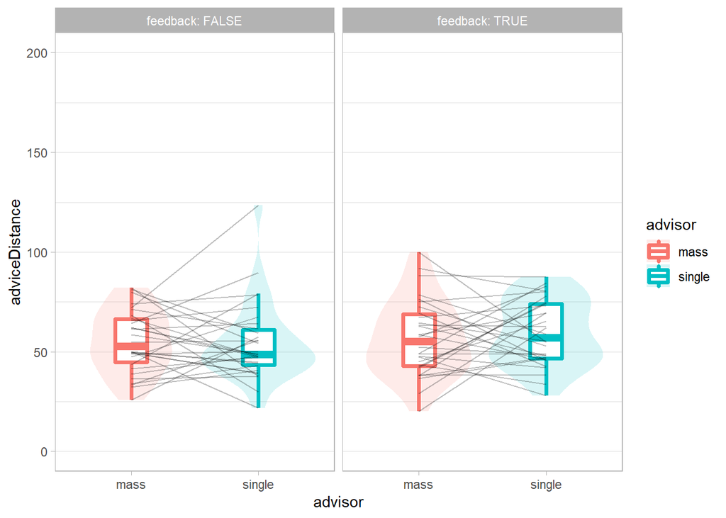

### Influence

The measure of influence is the extent to which a participant’s confidence moves in the expected direction as a function of the advice (increasing when agreed with, decreasing when disagreed with).

Influence is the primary outcome measure, and is thus expected to differ between advisors and feedback conditions.

| advisor0idDescription | feedback | advisorInfluence |
| --- | --- | --- |
| mass | FALSE | 22.4 |
| mass | TRUE | 29.0 |
| single | FALSE | 21.9 |
| single | TRUE | 23.5 |

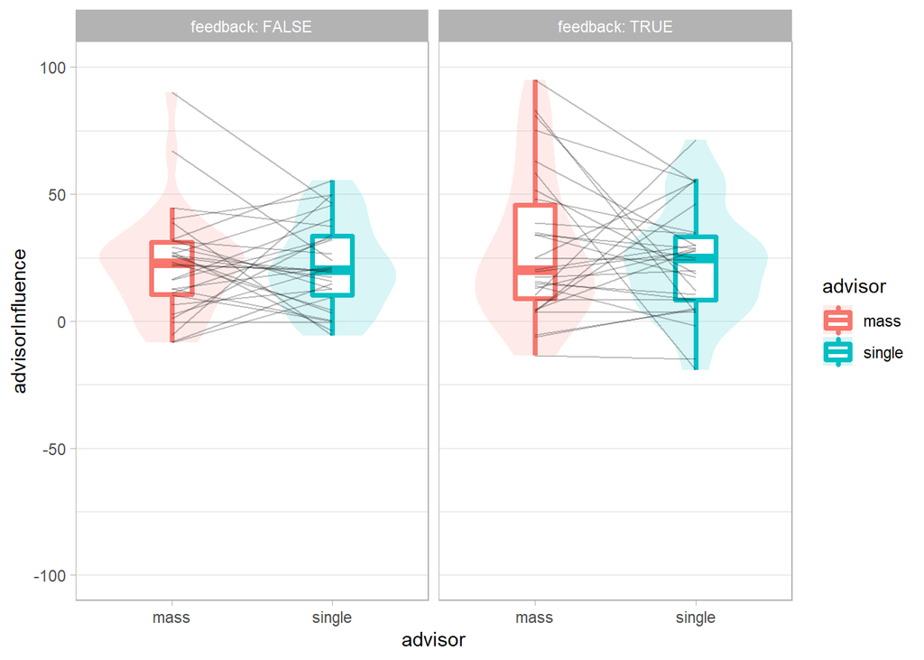

#### Influence distribution

It’s good to keep a general eye on the distribution of weight-on-advice on a trial-by-trial basis.

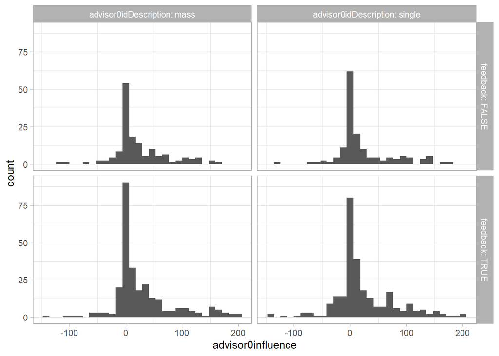

#### Is initial accuracy or initial confidence a better predictor of influence?

[output not shown]

## Hypothesis testing

The hypotheses being tested here are:

1. Participants will place higher weight on the advice of the single consistent advisor.

*t*(29) = -0.12, *p* = .906, *d* = 0.03, BF = 0.20; *M*|single = 21.91 [15.40, 28.42], *M*|mass = 22.42 [14.55, 30.29]

### Summary

# Conclusions

# Credits

## Acknowledgements

Thanks as always to Nick Yeung and the other folks at the [ACC Lab](https://www.psy.ox.ac.uk/research/attention-cognitive-control-lab).

## R Packages

| Package | Citations |
| --- | --- |
| base | R Core Team (2018). R: A language and environment for statistical computing. R Foundation for Statistical Computing, Vienna, Austria. URL https://www.R-project.org/. |
| beepr | Rasmus Bååth (2018). beepr: Easily Play Notification Sounds on any Platform. R package version 1.3. https://CRAN.R-project.org/package=beepr |
| curl | Jeroen Ooms (2019). curl: A Modern and Flexible Web Client for R. R package version 4.0. https://CRAN.R-project.org/package=curl |
| testthat | Hadley Wickham. testthat: Get Started with Testing. The R Journal, vol. 3, no. 1, pp. 5–10, 2011 |
| Hmisc | Frank E Harrell Jr, with contributions from Charles Dupont and many others. (2019). Hmisc: Harrell Miscellaneous. R package version 4.2-0. https://CRAN.R-project.org/package=Hmisc |
| Formula | Achim Zeileis, Yves Croissant (2010). Extended Model Formulas in R: Multiple Parts and Multiple Responses. Journal of Statistical Software 34(1), 1-13. doi:10.18637/jss.v034.i01 |
| survival | <br/><br/> |
| lattice | Sarkar, Deepayan (2008) Lattice: Multivariate Data Visualization with R. Springer, New York. ISBN 978-0-387-75968-5 |
| knitr | Yihui Xie (2019). knitr: A General-Purpose Package for Dynamic Report Generation in R. R package version 1.24.<br/><br/>Yihui Xie (2015) Dynamic Documents with R and knitr. 2nd edition. Chapman and Ha… |
| prettyMD | Matt Jaquiery (2020). prettyMD: Format Test Outputs with Markdown. R package version 0.1.2. |
| BayesFactor | Richard D. Morey and Jeffrey N. Rouder (2018). BayesFactor: Computation of Bayes Factors for Common Designs. R package version 0.9.12-4.2. https://CRAN.R-project.org/package=BayesFactor |
| Matrix | Douglas Bates and Martin Maechler (2019). Matrix: Sparse and Dense Matrix Classes and Methods. R package version 1.2-17. https://CRAN.R-project.org/package=Matrix |
| coda | Martyn Plummer, Nicky Best, Kate Cowles and Karen Vines (2006). CODA: Convergence Diagnosis and Output Analysis for MCMC, R News, vol 6, 7-11 |
| broom | David Robinson and Alex Hayes (2019). broom: Convert Statistical Analysis Objects into Tidy Tibbles. R package version 0.5.2. https://CRAN.R-project.org/package=broom |
| forcats | Hadley Wickham (2019). forcats: Tools for Working with Categorical Variables (Factors). R package version 0.4.0. https://CRAN.R-project.org/package=forcats |
| stringr | Hadley Wickham (2019). stringr: Simple, Consistent Wrappers for Common String Operations. R package version 1.4.0. https://CRAN.R-project.org/package=stringr |
| dplyr | Hadley Wickham, Romain François, Lionel Henry and Kirill Müller (2019). dplyr: A Grammar of Data Manipulation. R package version 0.8.3. https://CRAN.R-project.org/package=dplyr |
| purrr | Lionel Henry and Hadley Wickham (2019). purrr: Functional Programming Tools. R package version 0.3.3. https://CRAN.R-project.org/package=purrr |
| readr | Hadley Wickham, Jim Hester and Romain Francois (2018). readr: Read Rectangular Text Data. R package version 1.3.1. https://CRAN.R-project.org/package=readr |
| tidyr | Hadley Wickham and Lionel Henry (2019). tidyr: Easily Tidy Data with ‘spread()’ and ‘gather()’ Functions. R package version 0.8.3. https://CRAN.R-project.org/package=tidyr |
| tibble | Kirill Müller and Hadley Wickham (2019). tibble: Simple Data Frames. R package version 2.1.3. https://CRAN.R-project.org/package=tibble |
| ggplot2 | H. Wickham. ggplot2: Elegant Graphics for Data Analysis. Springer-Verlag New York, 2016. |
| tidyverse | Hadley Wickham (2017). tidyverse: Easily Install and Load the ‘Tidyverse’. R package version 1.2.1. https://CRAN.R-project.org/package=tidyverse |

## Funding

Matt Jaquiery is funded by a studentship from the [Medical Research Council](https://mrc.ukri.org/) (reference 1943590) and the University of Oxford [Department of Experimental Psychology](https://www.psy.ox.ac.uk/) (reference 17/18_MSD_661552).